# Logistics Regression - Loan Dataset

Dataset: Adult Data Set

https://archive.ics.uci.edu/ml/machine-learning-databases/adult/adult.data

Variable description:

age: continuous

workclass: Private, Self-emp-not-inc, Self-emp-inc, Federal-gov, Local-gov, State-gov, Without-pay, Never-worked.

fnlwgt: continuous.

education: Bachelors, Some-college, 11th, HS-grad, Prof-school, Assoc-acdm, Assoc-voc, 9th, 7th-8th, 12th, Masters, 1st-4th, 10th, Doctorate, 5th-6th, Preschool.

education-num: continuous.

marital-status: Married-civ-spouse, Divorced, Never-married, Separated, Widowed, Married-spouse-absent, Married-AF-spouse.

occupation: Tech-support, Craft-repair, Other-service, Sales, Exec-managerial, Prof-specialty, Handlers-cleaners, Machine-op-inspct, Adm-clerical, Farming-fishing, Transport-moving, Priv-house-serv, Protective-serv, Armed-Forces.

relationship: Wife, Own-child, Husband, Not-in-family, Other-relative, Unmarried.

race: White, Asian-Pac-Islander, Amer-Indian-Eskimo, Other, Black.

sex: Female, Male.

capital-gain: continuous.

capital-loss: continuous.

hours-per-week: continuous.

native-country: United-States, Cambodia, England, Puerto-Rico, Canada, Germany, Outlying-US(Guam-USVI-etc), India, Japan, Greece, South, China, Cuba, Iran, Honduras, Philippines, Italy, Poland, Jamaica, Vietnam, Mexico, Portugal, Ireland, France, Dominican-Republic, Laos, Ecuador, Taiwan, Haiti, Columbia, Hungary, Guatemala, Nicaragua, Scotland, Thailand, Yugoslavia, El-Salvador, Trinadad&Tobago, Peru, Hong, Holand-Netherlands.

class: >50K, <=50K

# Credit Dataset

Data Attributes:

Loan_ID Unique Loan ID

Gender Male/ Female

Married Applicant married (Y/N)

Dependents Number of dependents

Education Applicant Education (Graduate/ Undergraduate)

Self_Employed Self employed (Y/N)

ApplicantIncome Applicant income

1. CoapplicantIncome Coapplicant income
2. LoanAmount Loan amount in thousands
3. Loan_Amount_Term Term of loan in months
4. Credit_History credit history meets guidelines
5. Property_Area Urban/ Semi Urban/ Rural
6. Loan_Status Loan approved (Y/N)

```python
# Import the Libraries
import numpy as np
import pandas as pd
```

```python
# Lets Import the Dataset
credit = pd.read_csv("~/Downloads/CreditRisk.csv")
```

```python
credit.head()
```

|  | Loan_ID | Gender | Married | Dependents | Education | Self_Employed | ApplicantIncome | CoapplicantIncome | LoanAmount | Loan_Amount_Term | Credit_History | Property_Area | Loan_Status |
| --- | --- | --- | --- | --- | --- | --- | --- | --- | --- | --- | --- | --- | --- |
| 0 | LP001002 | Male | No | 0 | Graduate | No | 5849 | 0.0 | NaN | 360.0 | 1.0 | Urban | Y |
| 1 | LP001003 | Male | Yes | 1 | Graduate | No | 4583 | 1508.0 | 128.0 | 360.0 | 1.0 | Rural | N |
| 2 | LP001005 | Male | Yes | 0 | Graduate | Yes | 3000 | 0.0 | 66.0 | 360.0 | 1.0 | Urban | Y |
| 3 | LP001006 | Male | Yes | 0 | Not Graduate | No | 2583 | 2358.0 | 120.0 | 360.0 | 1.0 | Urban | Y |
| 4 | LP001008 | Male | No | 0 | Graduate | No | 6000 | 0.0 | 141.0 | 360.0 | 1.0 | Urban | Y |

```python
# Dimensions and Info
credit.shape
```

```
(614, 13)
```

```python
# Info
credit.info()
```

```
<class 'pandas.core.frame.DataFrame'>
RangeIndex: 614 entries, 0 to 613
Data columns (total 13 columns):
Loan_ID              614 non-null object
Gender               601 non-null object
Married              611 non-null object
Dependents           599 non-null object
Education            614 non-null object
Self_Employed        582 non-null object
ApplicantIncome      614 non-null int64
CoapplicantIncome    614 non-null float64
LoanAmount           592 non-null float64
Loan_Amount_Term     600 non-null float64
Credit_History       564 non-null float64
Property_Area        614 non-null object
Loan_Status          614 non-null object
dtypes: float64(4), int64(1), object(8)
memory usage: 62.4+ KB
```

## Missing Values

```python
# Check the Missing Values in the dataset
credit.isnull().sum() # count column wise
```

[output not shown]

```python
# Gender - Cat Variable
# Remember - In cat variable, we need to see which category has highest values.
# This is called finding the Mode. Highest Frequency cat. will be used to fill the Missing values.
credit.Gender.value_counts() # Mode value is "Male"
```

[output not shown]

```python
# Finding the Count of Missing G Values
credit.Gender.isnull().sum()
```

```
13
```

```python
# Impute Male in the 13 Missing Values - fillna
credit.Gender=credit.Gender.fillna("Male")
```

```python
# Married - Cat Variable
credit.Married.value_counts()
```

[output not shown]

```python
credit.Married.isnull().sum()
```

[output not shown]

```python
# Fill Na Values - Married
credit.Married = credit.Married.fillna("Yes")
```

```python
# Dependents
credit.Dependents.value_counts()
```

```
0     345
1     102
2     101
3+     51
Name: Dependents, dtype: int64
```

```python
credit.Dependents.isnull().sum()
```

[output not shown]

```python
credit.Dependents = credit.Dependents.fillna(0)
```

```python
credit.Self_Employed.value_counts()
```

```
No     500
Yes     82
Name: Self_Employed, dtype: int64
```

```python
credit.Self_Employed = credit.Self_Employed.fillna("No")
```

```python
# Loan Amount
credit.LoanAmount.describe()
# Mean > Median >Mode - +vely Skewed.
# Rule - In Normal Distribution, mean = median = mode
# Using Median to Impute the Missing Values in the Loan Amount
```

```
count    592.000000
mean     146.412162
std       85.587325
min        9.000000
25%      100.000000
50%      128.000000
75%      168.000000
max      700.000000
Name: LoanAmount, dtype: float64
```

```python
# Lets Plot this Data - distplot
import seaborn as sns
```

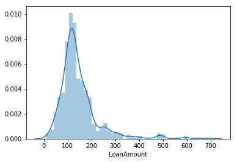

```python
sns.distplot(credit[credit.LoanAmount.notnull()].LoanAmount)
```

```python
credit.LoanAmount = credit.LoanAmount.fillna(credit.LoanAmount.median())
```

```python
credit.Loan_Amount_Term.describe() # Pattern is most of the Loans are of 30 years
```

```
count    600.00000
mean     342.00000
std       65.12041
min       12.00000
25%      360.00000
50%      360.00000
75%      360.00000
max      480.00000
Name: Loan_Amount_Term, dtype: float64
```

```python
credit.Loan_Amount_Term = credit.Loan_Amount_Term.fillna(360)
```

```python
credit.Credit_History.value_counts()
```

[output not shown]

```python
credit.Credit_History = credit.Credit_History.fillna(1.0)
```

```python
credit.head()
```

[output not shown]

# One Hot Encoding

1. We need to convert our data from strings to numbers. I need to apply Encoding to convert the Cat Variables into Binary Variables.
2. OHE is a process to convert the Cat Variables into Dummary (Binary 0 & 1) variables.

```python
# Target Column to Have Numerical Values  Y =1 and N = 0
credit.Loan_Status = credit.Loan_Status.replace({"Y": 1, "N":0})
```

```python
# dummies
#credit = credit.drop("Loan_ID", axis = 1)
newcredit = pd.get_dummies(credit)
```

```python
newcredit.head()
```

[output not shown]

5 rows × 22 columns

```python
newcredit.shape
```

```
(614, 22)
```

# Deploying Logistics Regression Model

1. From Data, define x and y.
2. Split the Data into Train -75% and Test - 25%. Random State = 0
3. Import the Logistics Reg from Sklearn.
4. Deply the Model and Make Predictions

```python
# Identifying the X and Y Values
x = newcredit.drop("Loan_Status", axis = 1)
y = newcredit.Loan_Status # This is what I want to predict
```

```python
# Split the Data into Train and Test
from sklearn.model_selection import train_test_split
xtrain,xtest,ytrain,ytest = train_test_split(x,y,test_size = 0.25, random_state = 0)
```

```python
# Import the Log Reg
from sklearn.linear_model import LogisticRegression
lg = LogisticRegression()
```

```python
# Fitting the Model so that the Machine (lg) is able to learn the pattern from the Training Data
lg.fit(xtrain,ytrain)
```

```
LogisticRegression(C=1.0, class_weight=None, dual=False, fit_intercept=True,
          intercept_scaling=1, max_iter=100, multi_class='ovr', n_jobs=1,
          penalty='l2', random_state=None, solver='liblinear', tol=0.0001,
          verbose=0, warm_start=False)
```

```python
model_lg = lg.predict(xtest)
```

```python
# If this would be a Regression Problem, we would have checked the R square
# It is a classification problem, we need to find the accuracy of the prediction
model_lg
```

```
array([1, 1, 1, 1, 1, 0, 1, 1, 0, 1, 1, 1, 1, 1, 1, 1, 1, 1, 1, 0, 0, 1,
       1, 1, 1, 1, 1, 1, 0, 0, 1, 1, 1, 1, 1, 0, 1, 1, 1, 1, 1, 0, 1, 1,
       1, 1, 1, 1, 1, 1, 1, 1, 1, 1, 1, 1, 1, 1, 1, 1, 0, 1, 1, 0, 1, 1,
       1, 1, 1, 1, 1, 1, 1, 1, 1, 1, 0, 1, 1, 0, 1, 1, 1, 1, 1, 1, 1, 1,
       1, 1, 1, 1, 1, 0, 1, 0, 1, 1, 1, 1, 1, 1, 1, 1, 1, 1, 1, 1, 1, 1,
       1, 1, 1, 1, 0, 0, 1, 1, 1, 1, 1, 0, 1, 1, 1, 0, 1, 1, 1, 1, 1, 1,
       1, 1, 1, 1, 1, 1, 1, 1, 1, 1, 0, 1, 1, 1, 1, 1, 0, 0, 1, 1, 1, 0])
```

# Classification Evaluation Model Metrics

```python
from sklearn.metrics import accuracy_score, cohen_kappa_score, confusion_matrix
```

```python
# Accuracy Score
accuracy_score(ytest,model_lg)* 100 # 83.76623376623377
```

```
83.76623376623377
```

```python
# Kappa Score
cohen_kappa_score(ytest,model_lg)
```

```
0.5257452574525745
```

### Kappa

1. Kappa Stats is the statistics that is used only in classification problems.
2. Generally the value of Kappa ranges from 0 and 1.
3. Higher the Value of Kappa, better the Model it is
4. At times, the accuracy is higher but Kappa value is lower (for e.g. 0.3 or 0.22)
5. If the Higher Kappa Value is with a Lower Accuracy Score, you can definitely conclude that model is a good model.

```python
# Confusion Matrix
confusion_matrix(ytest,model_lg)
```

```
array([[ 20,  23],
       [  2, 109]])
```

```python
(20+109)/(20+109+25)
```

```
0.8376623376623377
```